# Minería, Suelos y los Costos de la Transición

SUS 2211 — Mapeando la (in)sustentabilidad

Felipe Jordán

2026-04-13

## Plan para hoy

### Primer bloque

- A+R: Relaves bajo el cambio climático
- CT: Minería en Chile

### Segundo bloque

- CT: Contaminación de suelos
- Cápsula GIS: Operaciones espaciales
- Presentación Tarea 06

# A+R: Relaves Bajo el Cambio Climático

## Plenario

Algunas parejas comparten sus reflexiones.

- ¿Qué conexiones ven entre los relaves y lo discutido la clase pasada sobre la transición energética?
- ¿Cómo se relaciona con la idea de “Control y Descontrol”?

# CT: Minería en Chile

## Importancia económica de la minería

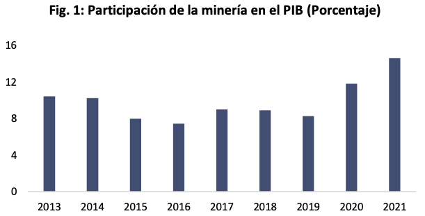

Fuente: COCHILCO (2022). Análisis de Impacto Socioeconómico de la Minería a Nivel Regional.

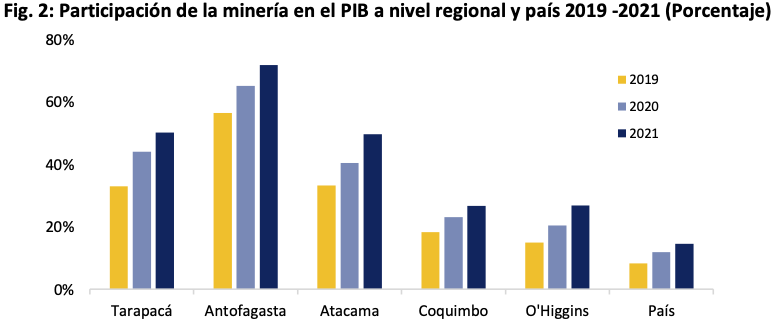

Fuente: COCHILCO (2022). Análisis de Impacto Socioeconómico de la Minería a Nivel Regional.

## Chile: economía minera

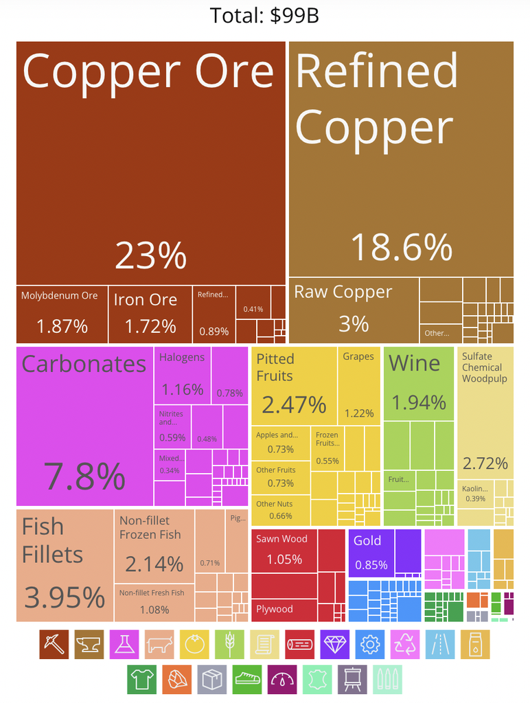

Fuente: OEC — Exportaciones de Chile (2022).

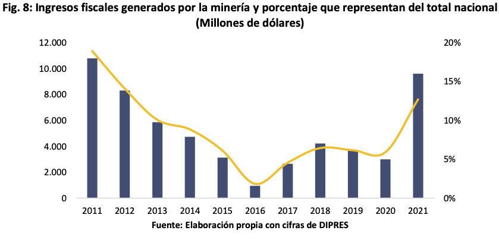

Fuente: COCHILCO (2022). Análisis de Impacto Socioeconómico de la Minería a Nivel Regional.

## La ley del mineral → 99% es relave

La ley del mineral es, por lo general, **menor a 1%**

Esto quiere decir que por cada kilo de mineral, se producen **99 kilos de relave**

Los relaves son tóxicos, por lo que es fundamental asegurar su **estabilidad química y física**

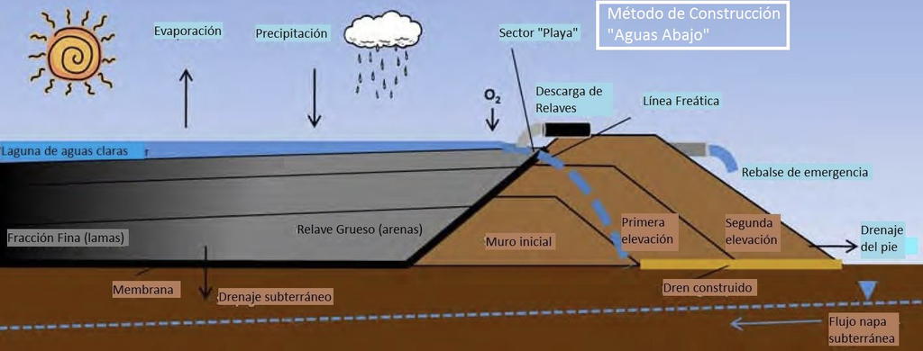

Fuente: SERNAGEOMIN — Preguntas frecuentes sobre relaves.

## ¿Cómo se ven los relaves?

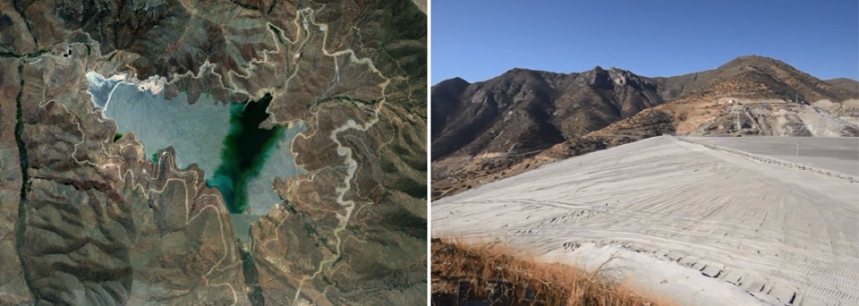

Minera Los Pelambres — Embalse El Mauro. Fuente: Consejo Minero.

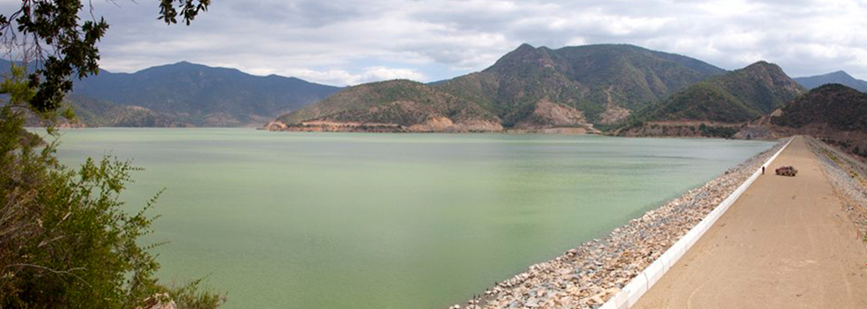

Minera El Teniente — Embalse Carén. Fuente: Consejo Minero.

## Estabilidad química y física

**Estabilidad Química**

Conseguir que los materiales depositados no aporten elementos o compuestos químicos al ecosistema circundante, por transporte aéreo (viento) ni por disolución hacia aguas del entorno (subterráneas o superficiales)

**Estabilidad Física**

Conseguir que el depósito de relaves no se desmorone ni se desborde

Fuente: SERNAGEOMIN — Preguntas frecuentes sobre relaves.

## ¿Por qué son tóxicos los relaves?

Si bien el relave no es considerado un Residuo Sólido Peligroso, dado que en un inicio es simplemente roca molida con agua, la roca contiene elementos tóxicos:

- **Arsénico**, cianuro, cobre, zinc, cromo y **plomo**
- Al reaccionar con el agua y el oxígeno, pueden **solubilizarse**
- Posibilitando su transporte por vía aérea o agua
- Potencialmente afectando a la población

Fuente: SERNAGEOMIN — Preguntas frecuentes sobre relaves.

## ¿Quiénes son más susceptibles?

Si bien todas las personas pueden ver su salud adversamente afectada por estos contaminantes, el efecto es particularmente dañino para los **niños**, dado que se encuentran en una **fase crítica de su desarrollo**

[figure not shown]

[figure not shown]

## Los relaves abandonados son los más peligrosos

Al pasar a ser inactivos (dejar de recibir la pulpa), las condiciones químicas del relave aumentan su **acidez**

La acidez, a su vez, aumenta la solubilidad de los elementos químicos tóxicos

Esto hace de los relaves abandonados **especialmente peligrosos**, dado que un relave debe ser gestionado activamente para mantener a raya su nivel de acidez y toxicidad

[figure not shown]

Fuente: DW — “Chile: resistirse a convivir con desechos mineros.”

## El nexo minería–transición energética

La clase pasada vimos que la transición energética necesita **enormes cantidades de minerales**:

- **Cobre** — cableado eléctrico, motores, paneles solares
- **Litio** — baterías de autos eléctricos y almacenamiento
- **Cobalto y níquel** — cátodos de baterías

Chile es el mayor productor mundial de cobre y el segundo de litio

[figure not shown]

[figure not shown]

## Minería… ¿sustentable?

> “Hemos tenido conversaciones sobre minería sostenible y minería verde. Y he dicho que prefiero no hablar en esos términos, que suenan a *greenwashing*, porque **la minería nunca es sostenible**. Necesitamos hablar de **minería responsable**. Sabemos que la minería tiene impactos importantes e irreversibles sobre la naturaleza. Necesitamos un acuerdo amplio sobre qué impactos estamos dispuestos a aceptar, y actuar con responsabilidad al respecto.”

— **Maisa Rojas**, Ministra del Medio Ambiente (2023)

## Reflexión en parejas

1. ¿Cuál es el rol de la minería en la transición hacia sociedades más sustentables?
2. ¿Cómo puede la minería disminuir sus impactos ambientales?
3. ¿Podría la minería considerarse sustentable?

## Mejoras en la industria minera

**Reducción del uso de agua**

Tecnologías de relaves espesados y filtrados, uso de agua de mar desalinizada, recirculación

**Descarbonización**

Chile tiene la ventaja de tener enorme potencial solar — las mineras del norte ya operan con energía renovable

Pero estos avances no resuelven el problema fundamental: la minería genera **residuos tóxicos** que deben ser gestionados **a perpetuidad**

## Transición: hacia la contaminación de suelos

La minería es una fuente importante de contaminación de suelos, pero no es la única

Chile avanza hacia una **Ley Marco de Suelos** que regulará:

- Identificación de sitios contaminados
- Responsabilidad por la remediación
- Estándares de calidad de suelos

Veamos el panorama más amplio de la contaminación de suelos…

# CT: Contaminación de Suelos

## Fuentes de contaminación de suelos

**Agricultura**

Pesticidas y fertilizantes — el mismo problema que denunció Rachel Carson en *Silent Spring*. Los agroquímicos se acumulan en el suelo y se filtran a las aguas subterráneas

**Silvicultura industrial**

Monocultivos forestales (pino, eucalipto) degradan el suelo: acidificación, pérdida de materia orgánica, erosión. Recordar el caso del territorio Mapuche (clase 03)

**Minería**

Relaves, drenaje ácido, polvo con metales pesados — lo que acabamos de revisar

**Residuos industriales**

Disposición inadecuada de desechos tóxicos, vertederos ilegales, pasivos ambientales históricos

## Caso: plomo en Arica

En los años 80, la empresa sueca **Boliden** envió más de 20.000 toneladas de **residuos tóxicos** con altas concentraciones de plomo, arsénico, cadmio y mercurio a Arica

Los desechos fueron almacenados por la empresa chilena **Promel** a cielo abierto, cerca de poblaciones

Posteriormente se construyeron **viviendas sociales** sobre y junto al sitio contaminado

- Los niños de la zona presentaron niveles de **plomo en sangre** muy por encima de los límites seguros
- Efectos: daño neurológico, problemas de aprendizaje, cáncer
- Un caso emblemático de **injusticia ambiental**: las víctimas son familias de bajos ingresos que no tuvieron elección sobre dónde vivir

## Arica: lecciones

El caso de Arica muestra cómo la contaminación de suelos puede ser **invisible** durante años, afectando a las comunidades más vulnerables

- La **responsabilidad** puede cruzar fronteras (Boliden es sueca)
- Los **costos de salud** los pagan las comunidades locales
- La **remediación** es costosa, lenta, y a menudo insuficiente

Este caso ilustra por qué Chile necesita una Ley Marco de Suelos con estándares claros y responsabilidades definidas.

# Cápsula GIS: Operaciones Espaciales

## Mapas base (basemaps)

Un **mapa base** es una capa de referencia visual que provee contexto geográfico (calles, topografía, imágenes satelitales)

En QGIS se añade con el complemento **QuickMapServices** (Web → QuickMapServices → OSM Standard)

**¿Por qué en escala de grises?**

Para que el mapa base no compita visualmente con los datos temáticos que queremos mostrar

Propiedades del raster → Simbología → Escala de grises

## Buffers: zonas de influencia

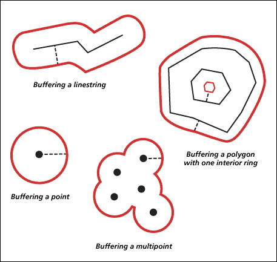

Un **buffer** genera un polígono representando un **área de influencia** a partir de una geometría

Ejemplo: ¿qué distritos censales están a menos de **5 km** de un relave?

→ Creamos un buffer de 5 km alrededor de cada relave

**Importante:** para que la distancia tenga sentido, la capa debe estar en un **CRS proyectado** (metros), no geográfico (grados)

## Uniones espaciales

Una de las operaciones más poderosas de SIG es unir capas de información utilizando su **relación espacial**

A la relación se le llama **predicado**:

- **Intersecta** — las geometrías se tocan o superponen
- **Contiene** — TARGET encierra completamente a JOIN
- **Está dentro** — TARGET está completamente dentro de JOIN
- **Toca** — las geometrías comparten borde pero no interior

## Interior y borde

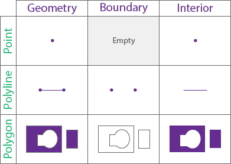

Toda geometría tiene un interior y un borde. Los predicados espaciales se definen según cómo se relacionan estos componentes. Fuente: ArcGIS Enterprise.

## Predicado: Intersección

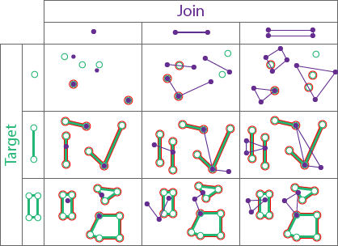

¿TARGET intersecciona a JOIN? Verdadero si comparten cualquier punto en común (interior o borde). Fuente: ArcGIS Enterprise.

## Predicado: Contiene

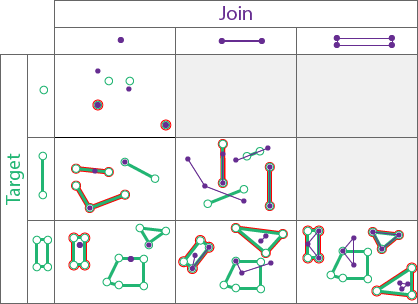

¿TARGET contiene a JOIN? Verdadero si JOIN está completamente dentro del interior de TARGET. Fuente: ArcGIS Enterprise.

## Predicado: Dentro

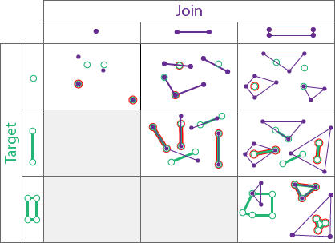

¿TARGET está dentro de JOIN? El inverso de “contiene”. Fuente: ArcGIS Enterprise.

## Predicado: Toca

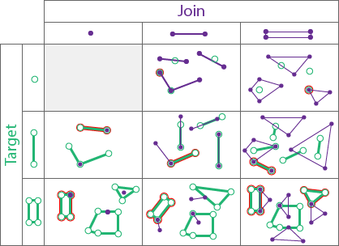

¿TARGET toca a JOIN? Verdadero si comparten borde pero no interior. Fuente: ArcGIS Enterprise.

## Ejemplo: unión espacial por intersección

Queremos unir la capa de **distritos censales** con el **buffer de 5 km** de los relaves

Objetivo: identificar qué distritos están a menos de 5 km de un relave

Resultado: cada distrito que intersecta *n* relaves aparece *n* veces en la tabla

## ¿Qué pasa con la tabla de atributos?

Distrito 4202_7: no intersecta ningún relave → aparece 1 vez, columnas de relaves con valores nulos.

Distrito 4202_12: intersecta 2 relaves → aparece 2 veces.

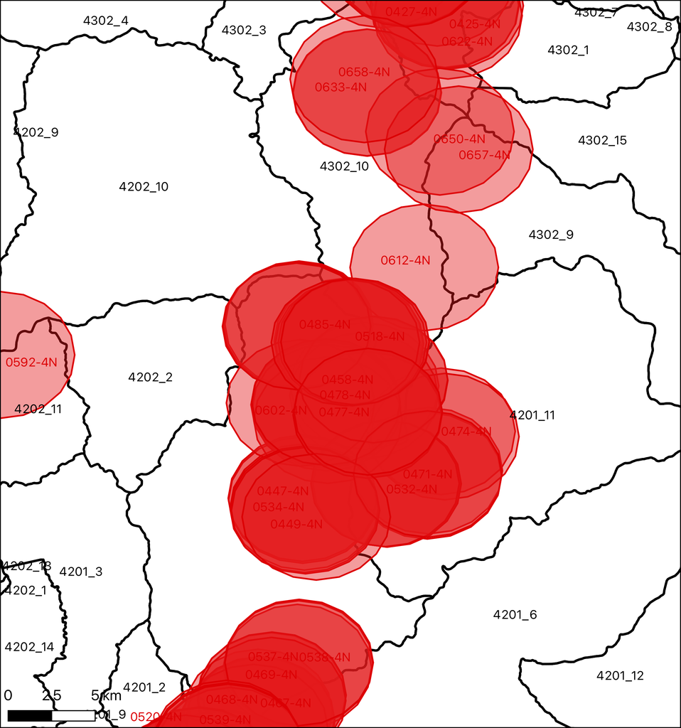

Distrito 4201_5: intersecta 62 relaves → aparece 62 veces.

# Presentación Tarea 06

## Tarea 06: Minería, Relaves y Población Expuesta

**¿Qué van a construir?**

Un **díptico** con dos mapas de la Región de Coquimbo:

1. **Mapa de exposición:** distritos censales dentro de la zona de influencia de 5 km de los relaves
2. **Mapa de vulnerabilidad:** niños de 0–5 años en distritos expuestos (símbolos proporcionales)

**Herramientas nuevas:**

- QuickMapServices + mapa base en escala de grises
- Selección por localización
- Reproyección a CRS proyectado (EPSG:32719)
- Buffer (zona de influencia)
- Unión espacial (*Join Attributes by Location*)
- Símbolos proporcionales con expresión SQL
- Calculadora de campos
- Simbología categorizada con expresión

## Flujo de trabajo

1. Cargar capas (relaves, distritos censales, población) + mapa base
2. **Reproyectar** a UTM zona 19S para trabajar en metros
3. Crear **buffer de 5 km** alrededor de los relaves
4. **Unión espacial** para transferir información de relaves a distritos
5. **Calculadora de campos** para agregar conteos
6. **Clasificar** distritos como expuestos / no expuestos
7. **Composición** del díptico horizontal

## Entregable

- Un **díptico horizontal** (paisaje) con ambos mapas
- Exportado como imagen o PDF desde el compositor de impresión de QGIS
- Subido a **Canvas** antes de la fecha límite

La guía paso a paso está disponible en Canvas. Descarguen también el archivo `.zip` con los datos.